# Exploration into microbiome qvalues

Claire Duvallet

December 13, 2017

In this notebook, I want to see what’s going on with all the different methods for three microbiome datasets. It seems that the two datasets I’ve used so far (ob_goodrich, with ~70,000 OTUs but very few true differentially abundant OTUs, and cdi_schubert, with ~18,000 OTUs and very many true differentially abundant OTUs) are getting weird results in different ways and with different methods.

My hypotheses so far are that:

- ash is rejecting all hypotheses
- True
- lfdr is also being affected by the `nmids`/`df` [error](https://github.com/pkimes/benchmark-fdr/issues/16#issuecomment-345844180)
- probably not a problem
- decreasing nmids doesn’t fix the error/problem with Scott (FDRreg)
- True

To look into these, I’ll run SummarizedBenchmark for each value of nmids (5, 50, 150) for each dataset, and plot histograms of the resulting q values for each method.

Note that I ran SummarizedBenchmark for different values of nmids in `microbiome-SummarizedBenchmark.Rmd` and saved the results to files.

```r
library(dplyr)
library(ggplot2)

library(SummarizedBenchmark)

setwd("/Users/claire/github/benchmark-fdr/datasets/microbiome/")
datdir <- "/Users/claire/github/benchmark-fdr/datasets/microbiome/DATA/"
resdir <- "/Users/claire/github/benchmark-fdr/datasets/microbiome/RESULTS/"
```

# CDI Schubert

```r
dflst = list()
i <- 1
for (nmids in c(5, 50, 150)){
  print(nmids)
  resfile <- paste0(resdir, "schubert_summarizedBenchmark_",
                    "18703", "_nmids_", nmids, ".RData")
  load(resfile)

  # Extract qvalues and melt into tidy dataframe
  qvals <- assay(sb) %>% as.data.frame %>% gather("method", "qval")
  qvals$nmids <- nmids

  # TO DO: add/concatenate to other things?
  dflst[[i]] <- qvals
  i <- i + 1
}
```

```
## [1] 5
## [1] 50
## [1] 150
```

```r
allres <- bind_rows(dflst)
```

```r
nmids_qvals <- c()
# First, check which methods are affected by nmids
for (met in unique(allres$method)){
  n5 <- allres %>% filter(method == met) %>% filter(nmids == 5)
  n50 <- allres %>% filter(method == met) %>% filter(nmids == 50)
  n150 <- allres %>% filter(method == met) %>% filter(nmids == 150)
  if (!(n5$qval == n50$qval && n50$qval == n150$qval) | is.na(n5$qval == n50$qval && n50$qval == n150$qval)){
    nmids_qvals <- c(nmids_qvals, met)
  }
}
nmids_qvals
```

```
## [1] "lfdr"              "scott-theoretical" "scott-empirical"
```

## scott and lfdr (are messed up)

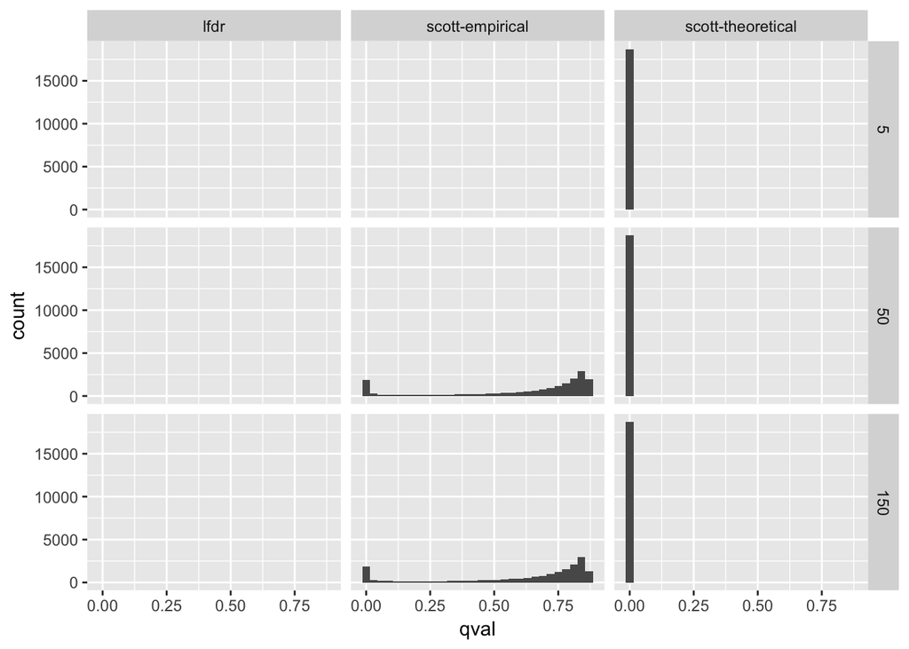

```r
allres %>%
  filter(method %in% nmids_qvals) %>%
  #mutate(logqval = log10(qval)) %>%
  ggplot(aes(x=qval)) + geom_histogram() + facet_grid(nmids ~ method)
```

```r
## Look at number of NaN q-values for each method
allres %>% filter(method %in% c(nmids_qvals, "ashs")) %>% group_by(method, nmids) %>% summarize(n_nan = sum(is.na(qval)))
```

```
## # A tibble: 12 x 3
## # Groups:   method [?]
##               method nmids n_nan
##                <chr> <dbl> <int>
##  1              ashs     5     0
##  2              ashs    50     0
##  3              ashs   150     0
##  4              lfdr     5 18703
##  5              lfdr    50 18703
##  6              lfdr   150 18703
##  7   scott-empirical     5 18703
##  8   scott-empirical    50     0
##  9   scott-empirical   150     0
## 10 scott-theoretical     5     0
## 11 scott-theoretical    50     0
## 12 scott-theoretical   150     0
```

### ashs (return all q-values = 0)

And one final note: all ashs qvalues are basically 0…

```r
allres %>% filter(method == "ashs") %>% group_by(nmids) %>% summarize(min = min(qval), max = max(qval))
```

```
## # A tibble: 3 x 3
##   nmids   min          max
##   <dbl> <dbl>        <dbl>
## 1     5     0 8.904104e-19
## 2    50     0 8.904104e-19
## 3   150     0 8.904104e-19
```

### All other methods (seem OK)

Let’s also plot the q-value distributions for all methods.

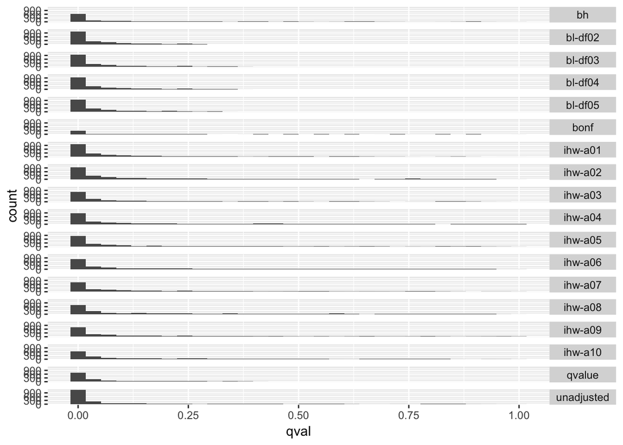

```r
allres %>%
  filter(!method %in% nmids_qvals) %>%
  filter(!method == "ashs") %>%
  #filter(!method == "unadjusted") %>%
  group_by(method, qval) %>% filter(row_number() == 1) %>%
  ggplot(aes(x=qval)) + geom_histogram() + facet_grid(method ~ .) + theme(strip.text.y = element_text(angle = 0))
```

# OB Goodrich

```r
dflst = list()
i <- 1
for (nmids in c(5, 50, 150)){
  print(nmids)
  resfile <- paste0(resdir, "goodrich_summarizedBenchmark_",
                    "71710", "_nmids_", nmids, ".RData")
  load(resfile)

  # Extract qvalues and melt into tidy dataframe
  qvals <- assay(sb) %>% as.data.frame %>% gather("method", "qval")
  qvals$nmids <- nmids

  # TO DO: add/concatenate to other things?
  dflst[[i]] <- qvals
  i <- i + 1
}
```

```
## [1] 5
## [1] 50
## [1] 150
```

```r
allres <- bind_rows(dflst)
```

```r
nmids_qvals <- c()
# First, check which methods are affected by nmids
for (met in unique(allres$method)){
  n5 <- allres %>% filter(method == met) %>% filter(nmids == 5)
  n50 <- allres %>% filter(method == met) %>% filter(nmids == 50)
  n150 <- allres %>% filter(method == met) %>% filter(nmids == 150)
  if (!(n5$qval == n50$qval && n50$qval == n150$qval) | is.na(n5$qval == n50$qval && n50$qval == n150$qval)){
    nmids_qvals <- c(nmids_qvals, met)
  }
}
nmids_qvals
```

```
## [1] "lfdr"              "scott-theoretical" "scott-empirical"
```

## scott and lfdr (are messed up)

LFDR seems to work okay (though its values do depend on nmids), but Scott either returns all NaN’s or all zeros…

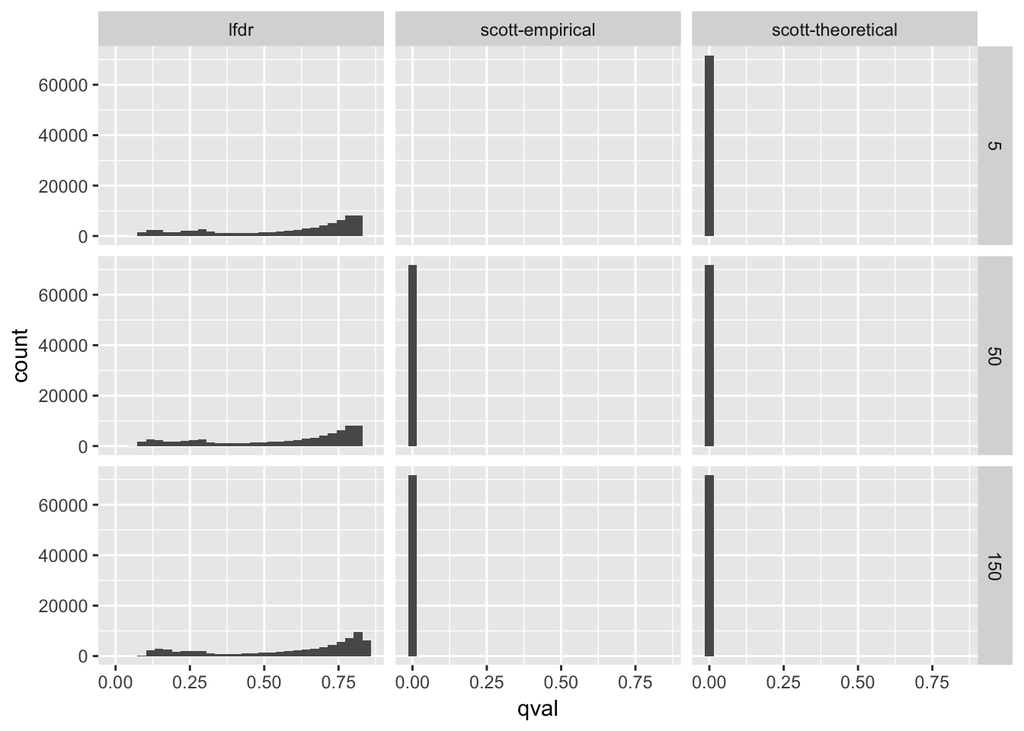

```r
allres %>%
  filter(method %in% nmids_qvals) %>%
  #mutate(logqval = log10(qval)) %>%
  ggplot(aes(x=qval)) + geom_histogram() + facet_grid(nmids ~ method)
```

```r
## Look at number of NaN q-values for each method
allres %>% filter(method %in% c(nmids_qvals, "ashs")) %>% group_by(method, nmids) %>% summarize(n_nan = sum(is.na(qval)))
```

```
## # A tibble: 12 x 3
## # Groups:   method [?]
##               method nmids n_nan
##                <chr> <dbl> <int>
##  1              ashs     5     0
##  2              ashs    50     0
##  3              ashs   150     0
##  4              lfdr     5     0
##  5              lfdr    50     0
##  6              lfdr   150     0
##  7   scott-empirical     5 71710
##  8   scott-empirical    50     0
##  9   scott-empirical   150     0
## 10 scott-theoretical     5     0
## 11 scott-theoretical    50     0
## 12 scott-theoretical   150     0
```

### ashs (return all q-values = 0)

And one final note: all ashs qvalues are basically 0…

```r
allres %>% filter(method == "ashs") %>% group_by(nmids) %>% summarize(min = min(qval), max = max(qval))
```

```
## # A tibble: 3 x 3
##   nmids   min          max
##   <dbl> <dbl>        <dbl>
## 1     5     0 6.234979e-06
## 2    50     0 6.234979e-06
## 3   150     0 6.234979e-06
```

### All other methods (seem OK)

Let’s also plot the q-value distributions for all methods.

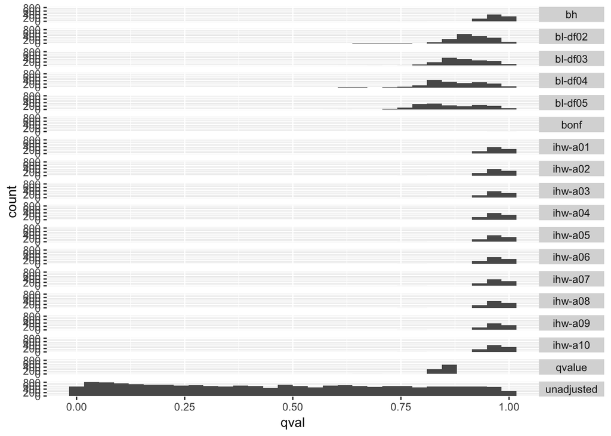

```r
allres %>%
  filter(!method %in% nmids_qvals) %>%
  filter(!method == "ashs") %>%
  #filter(!method == "unadjusted") %>%
  group_by(method, qval) %>% filter(row_number() == 1) %>%
  ggplot(aes(x=qval)) + geom_histogram() + facet_grid(method ~ .) + theme(strip.text.y = element_text(angle = 0))
```